# ISLR Chapter 6.rmd

Alex Bayers

10/27/2018

## Chapter 6 Problems

### Problem 1

##### 1

1. By definition, the best subset model will have the lowest training error since it is the model that fits the best on that data.
2. Uncertain - depending on the model structure any of them can fit the best.
3. 1. True #####2 True #####3 False - there isn’t necessarily any relationship. #####4 False #####5 False - the active set can change easily.

#### Problem 2

1. 1. It is less flexible, so this statment is false.
2. False - again it is still less flexible.
3. True - it is less flexible, and is not an unbiased estimator.
4. Flase - it has less variance than the least squares estimator.
2. 1. False, it’s less flexible.
2. False, it’s less flexible.
3. True.
4. False
5. 1. False - more variance, less bias
6. True - more bias, more flexible.
7. False - it’s more flexible.
8. False - it’s more flexible.

### Problem 3

1. iv is correct.
2. ii or iv is correct - RSS will decrease as s increases, but it’s unclear what the asymptotic behavior will be.
3. Variance will steadily increase
4. Bias will steadily decrease
5. Irreducible error will remain constant.

### Problem 4

1. iii b, ii
2. iv
3. iii
4. v

### Problem 8

###### A & B

```r
set.seed(2)
b0 <- rnorm(1)
b1 <- rnorm(1)
b2 <- rnorm(1)
b3 <- rnorm(1)
x <- rnorm(100)
e <- rnorm(100)
y <- b0 + b1*x + b2*x^2 +b3*x^3 + e
print(c(b0, b1, b2, b3))
```

```
## [1] -0.8969145  0.1848492  1.5878453 -1.1303757
```

The model we’re fitting is -0.8969145 + 0.1848492 * x + 1.5878453 * x^2 -1.1303757 * x^3

##### C

```r
library(leaps)
reg_data <- data.frame(y, x)
reg_model <- regsubsets(y ~ poly(x, 10, raw = TRUE), data = reg_data)
reg_summary <- summary(reg_model)
print(reg_summary)
```

```
## Subset selection object
## Call: regsubsets.formula(y ~ poly(x, 10, raw = TRUE), data = reg_data)
## 10 Variables  (and intercept)
##                           Forced in Forced out
## poly(x, 10, raw = TRUE)1      FALSE      FALSE
## poly(x, 10, raw = TRUE)2      FALSE      FALSE
## poly(x, 10, raw = TRUE)3      FALSE      FALSE
## poly(x, 10, raw = TRUE)4      FALSE      FALSE
## poly(x, 10, raw = TRUE)5      FALSE      FALSE
## poly(x, 10, raw = TRUE)6      FALSE      FALSE
## poly(x, 10, raw = TRUE)7      FALSE      FALSE
## poly(x, 10, raw = TRUE)8      FALSE      FALSE
## poly(x, 10, raw = TRUE)9      FALSE      FALSE
## poly(x, 10, raw = TRUE)10     FALSE      FALSE
## 1 subsets of each size up to 8
## Selection Algorithm: exhaustive
##          poly(x, 10, raw = TRUE)1 poly(x, 10, raw = TRUE)2
## 1  ( 1 ) " "                      " "
## 2  ( 1 ) " "                      "*"
## 3  ( 1 ) " "                      "*"
## 4  ( 1 ) "*"                      "*"
## 5  ( 1 ) "*"                      "*"
## 6  ( 1 ) "*"                      "*"
## 7  ( 1 ) "*"                      "*"
## 8  ( 1 ) "*"                      "*"
##          poly(x, 10, raw = TRUE)3 poly(x, 10, raw = TRUE)4
## 1  ( 1 ) " "                      " "
## 2  ( 1 ) "*"                      " "
## 3  ( 1 ) "*"                      " "
## 4  ( 1 ) " "                      " "
## 5  ( 1 ) " "                      " "
## 6  ( 1 ) " "                      "*"
## 7  ( 1 ) "*"                      " "
## 8  ( 1 ) " "                      "*"
##          poly(x, 10, raw = TRUE)5 poly(x, 10, raw = TRUE)6
## 1  ( 1 ) "*"                      " "
## 2  ( 1 ) " "                      " "
## 3  ( 1 ) "*"                      " "
## 4  ( 1 ) "*"                      " "
## 5  ( 1 ) "*"                      " "
## 6  ( 1 ) "*"                      " "
## 7  ( 1 ) " "                      " "
## 8  ( 1 ) "*"                      "*"
##          poly(x, 10, raw = TRUE)7 poly(x, 10, raw = TRUE)8
## 1  ( 1 ) " "                      " "
## 2  ( 1 ) " "                      " "
## 3  ( 1 ) " "                      " "
## 4  ( 1 ) "*"                      " "
## 5  ( 1 ) "*"                      " "
## 6  ( 1 ) " "                      " "
## 7  ( 1 ) "*"                      "*"
## 8  ( 1 ) " "                      "*"
##          poly(x, 10, raw = TRUE)9 poly(x, 10, raw = TRUE)10
## 1  ( 1 ) " "                      " "
## 2  ( 1 ) " "                      " "
## 3  ( 1 ) " "                      " "
## 4  ( 1 ) " "                      " "
## 5  ( 1 ) " "                      "*"
## 6  ( 1 ) "*"                      "*"
## 7  ( 1 ) "*"                      "*"
## 8  ( 1 ) "*"                      "*"
```

```r
par(mfrow=c(2,2))
plot(reg_summary$cp, type = "l")
points(which.min(reg_summary$cp), reg_summary$cp[which.min(reg_summary$cp)], col="red",cex=2,pch=20)
plot(reg_summary$bic, type = "l")
points(which.min(reg_summary$bic), reg_summary$bic[which.min(reg_summary$bic)], col="red",cex=2,pch=20)
plot(reg_summary$adjr2, type = "l")
points(which.max(reg_summary$adjr2), reg_summary$adjr2[which.max(reg_summary$adjr2)], col="red",cex=2,pch=20)

#Results for the cp, bic model
coef(reg_model, 2)
```

```
##              (Intercept) poly(x, 10, raw = TRUE)2 poly(x, 10, raw = TRUE)3
##               -0.9271256                1.6448130               -1.0968059
```

```r
#Results for the r^2 model
coef(reg_model, 4)
```

```
##              (Intercept) poly(x, 10, raw = TRUE)1 poly(x, 10, raw = TRUE)2
##              -0.93728643              -0.61602905               1.64565275
## poly(x, 10, raw = TRUE)5 poly(x, 10, raw = TRUE)7
##              -0.38978468               0.03729776
```

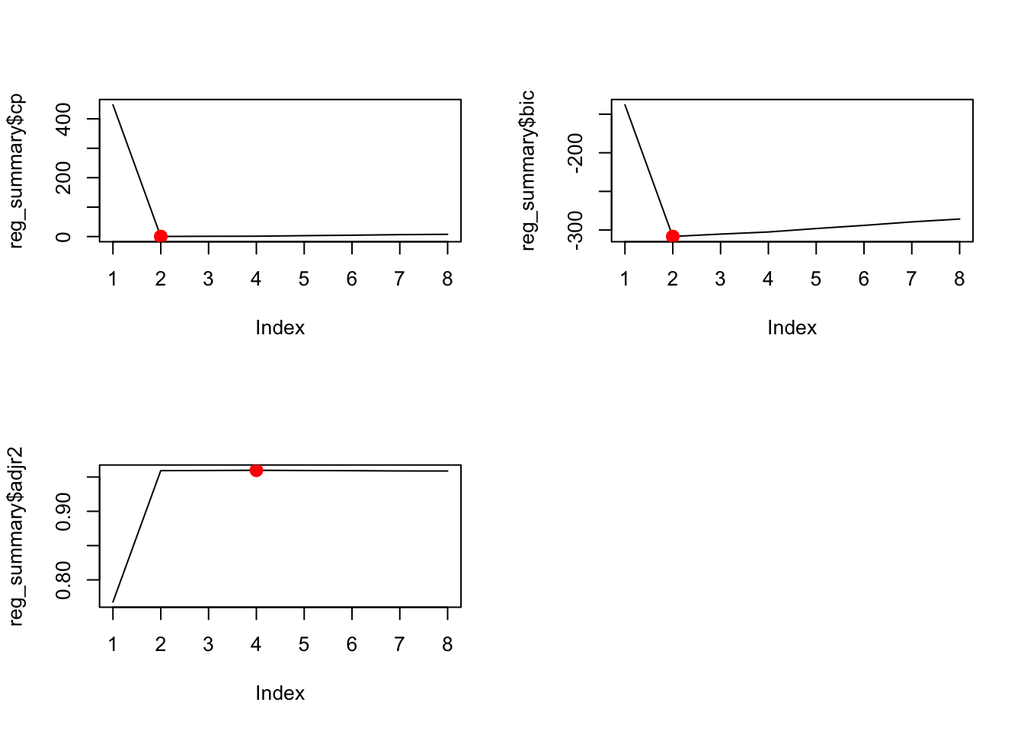

Cp implies two terms - second and third degree terms. Our model is the following.

-0.9271256 + 1.6448130 * x^2 - 1.0968059 * x^3

Which seems consistent with the model we’re generating the data from.

Adjusted-R^2 implies four terms - first, second, fifth, and seventh degree terms.

-0.93728643 + -0.61602905*x + 1.64565275* x^2 + -0.38978468 * x^5 + 0.03729776 * x^7

Which seems like a much worse fit the Cp/BIC implied model.

#####D

```r
model_matrix <- model.matrix(y ~ poly(x, 10, raw = TRUE), data = reg_data)
fwd_model <- regsubsets(y ~ poly(x, 10, raw = TRUE), data = reg_data, method = "forward")
bkwd_model <- regsubsets(y ~ poly(x, 10, raw = TRUE), data = reg_data, method = "backward")
fwd_summary <- summary(fwd_model)
bkwd_summary <- summary(bkwd_model)
print(fwd_summary)
```

```
## Subset selection object
## Call: regsubsets.formula(y ~ poly(x, 10, raw = TRUE), data = reg_data,
##     method = "forward")
## 10 Variables  (and intercept)
##                           Forced in Forced out
## poly(x, 10, raw = TRUE)1      FALSE      FALSE
## poly(x, 10, raw = TRUE)2      FALSE      FALSE
## poly(x, 10, raw = TRUE)3      FALSE      FALSE
## poly(x, 10, raw = TRUE)4      FALSE      FALSE
## poly(x, 10, raw = TRUE)5      FALSE      FALSE
## poly(x, 10, raw = TRUE)6      FALSE      FALSE
## poly(x, 10, raw = TRUE)7      FALSE      FALSE
## poly(x, 10, raw = TRUE)8      FALSE      FALSE
## poly(x, 10, raw = TRUE)9      FALSE      FALSE
## poly(x, 10, raw = TRUE)10     FALSE      FALSE
## 1 subsets of each size up to 8
## Selection Algorithm: forward
##          poly(x, 10, raw = TRUE)1 poly(x, 10, raw = TRUE)2
## 1  ( 1 ) " "                      " "
## 2  ( 1 ) " "                      "*"
## 3  ( 1 ) " "                      "*"
## 4  ( 1 ) " "                      "*"
## 5  ( 1 ) "*"                      "*"
## 6  ( 1 ) "*"                      "*"
## 7  ( 1 ) "*"                      "*"
## 8  ( 1 ) "*"                      "*"
##          poly(x, 10, raw = TRUE)3 poly(x, 10, raw = TRUE)4
## 1  ( 1 ) " "                      " "
## 2  ( 1 ) " "                      " "
## 3  ( 1 ) "*"                      " "
## 4  ( 1 ) "*"                      " "
## 5  ( 1 ) "*"                      " "
## 6  ( 1 ) "*"                      " "
## 7  ( 1 ) "*"                      " "
## 8  ( 1 ) "*"                      " "
##          poly(x, 10, raw = TRUE)5 poly(x, 10, raw = TRUE)6
## 1  ( 1 ) "*"                      " "
## 2  ( 1 ) "*"                      " "
## 3  ( 1 ) "*"                      " "
## 4  ( 1 ) "*"                      " "
## 5  ( 1 ) "*"                      " "
## 6  ( 1 ) "*"                      " "
## 7  ( 1 ) "*"                      " "
## 8  ( 1 ) "*"                      " "
##          poly(x, 10, raw = TRUE)7 poly(x, 10, raw = TRUE)8
## 1  ( 1 ) " "                      " "
## 2  ( 1 ) " "                      " "
## 3  ( 1 ) " "                      " "
## 4  ( 1 ) " "                      " "
## 5  ( 1 ) " "                      " "
## 6  ( 1 ) "*"                      " "
## 7  ( 1 ) "*"                      " "
## 8  ( 1 ) "*"                      "*"
##          poly(x, 10, raw = TRUE)9 poly(x, 10, raw = TRUE)10
## 1  ( 1 ) " "                      " "
## 2  ( 1 ) " "                      " "
## 3  ( 1 ) " "                      " "
## 4  ( 1 ) "*"                      " "
## 5  ( 1 ) "*"                      " "
## 6  ( 1 ) "*"                      " "
## 7  ( 1 ) "*"                      "*"
## 8  ( 1 ) "*"                      "*"
```

```r
print(bkwd_summary)
```

```
## Subset selection object
## Call: regsubsets.formula(y ~ poly(x, 10, raw = TRUE), data = reg_data,
##     method = "backward")
## 10 Variables  (and intercept)
##                           Forced in Forced out
## poly(x, 10, raw = TRUE)1      FALSE      FALSE
## poly(x, 10, raw = TRUE)2      FALSE      FALSE
## poly(x, 10, raw = TRUE)3      FALSE      FALSE
## poly(x, 10, raw = TRUE)4      FALSE      FALSE
## poly(x, 10, raw = TRUE)5      FALSE      FALSE
## poly(x, 10, raw = TRUE)6      FALSE      FALSE
## poly(x, 10, raw = TRUE)7      FALSE      FALSE
## poly(x, 10, raw = TRUE)8      FALSE      FALSE
## poly(x, 10, raw = TRUE)9      FALSE      FALSE
## poly(x, 10, raw = TRUE)10     FALSE      FALSE
## 1 subsets of each size up to 8
## Selection Algorithm: backward
##          poly(x, 10, raw = TRUE)1 poly(x, 10, raw = TRUE)2
## 1  ( 1 ) " "                      " "
## 2  ( 1 ) " "                      "*"
## 3  ( 1 ) " "                      "*"
## 4  ( 1 ) " "                      "*"
## 5  ( 1 ) " "                      "*"
## 6  ( 1 ) " "                      "*"
## 7  ( 1 ) " "                      "*"
## 8  ( 1 ) " "                      "*"
##          poly(x, 10, raw = TRUE)3 poly(x, 10, raw = TRUE)4
## 1  ( 1 ) "*"                      " "
## 2  ( 1 ) "*"                      " "
## 3  ( 1 ) "*"                      " "
## 4  ( 1 ) "*"                      " "
## 5  ( 1 ) "*"                      " "
## 6  ( 1 ) "*"                      "*"
## 7  ( 1 ) "*"                      "*"
## 8  ( 1 ) "*"                      "*"
##          poly(x, 10, raw = TRUE)5 poly(x, 10, raw = TRUE)6
## 1  ( 1 ) " "                      " "
## 2  ( 1 ) " "                      " "
## 3  ( 1 ) " "                      " "
## 4  ( 1 ) " "                      " "
## 5  ( 1 ) " "                      "*"
## 6  ( 1 ) " "                      "*"
## 7  ( 1 ) " "                      "*"
## 8  ( 1 ) " "                      "*"
##          poly(x, 10, raw = TRUE)7 poly(x, 10, raw = TRUE)8
## 1  ( 1 ) " "                      " "
## 2  ( 1 ) " "                      " "
## 3  ( 1 ) "*"                      " "
## 4  ( 1 ) "*"                      "*"
## 5  ( 1 ) "*"                      "*"
## 6  ( 1 ) "*"                      "*"
## 7  ( 1 ) "*"                      "*"
## 8  ( 1 ) "*"                      "*"
##          poly(x, 10, raw = TRUE)9 poly(x, 10, raw = TRUE)10
## 1  ( 1 ) " "                      " "
## 2  ( 1 ) " "                      " "
## 3  ( 1 ) " "                      " "
## 4  ( 1 ) " "                      " "
## 5  ( 1 ) " "                      " "
## 6  ( 1 ) " "                      " "
## 7  ( 1 ) " "                      "*"
## 8  ( 1 ) "*"                      "*"
```

```r
#Plots for forward summary
par(mfrow=c(2,2))
plot(fwd_summary$cp, type = "l")
points(which.min(fwd_summary$cp), fwd_summary$cp[which.min(fwd_summary$cp)], col="red",cex=2,pch=20)
plot(fwd_summary$bic, type = "l")
points(which.min(fwd_summary$bic), fwd_summary$bic[which.min(fwd_summary$bic)], col="red",cex=2,pch=20)
plot(fwd_summary$adjr2, type = "l")
points(which.max(fwd_summary$adjr2), fwd_summary$adjr2[which.max(fwd_summary$adjr2)], col="red",cex=2,pch=20)
coef_fwd=coef(fwd_model, 3)
coef_fwd
```

```
##              (Intercept) poly(x, 10, raw = TRUE)2 poly(x, 10, raw = TRUE)3
##              -0.89634772               1.61126845              -0.96515559
## poly(x, 10, raw = TRUE)5
##              -0.03129297
```

```r
pred_fwd=model_matrix[,names(coef_fwd)]%*%coef_fwd
mean((y-pred_fwd)^2)
```

```
## [1] 1.016438
```

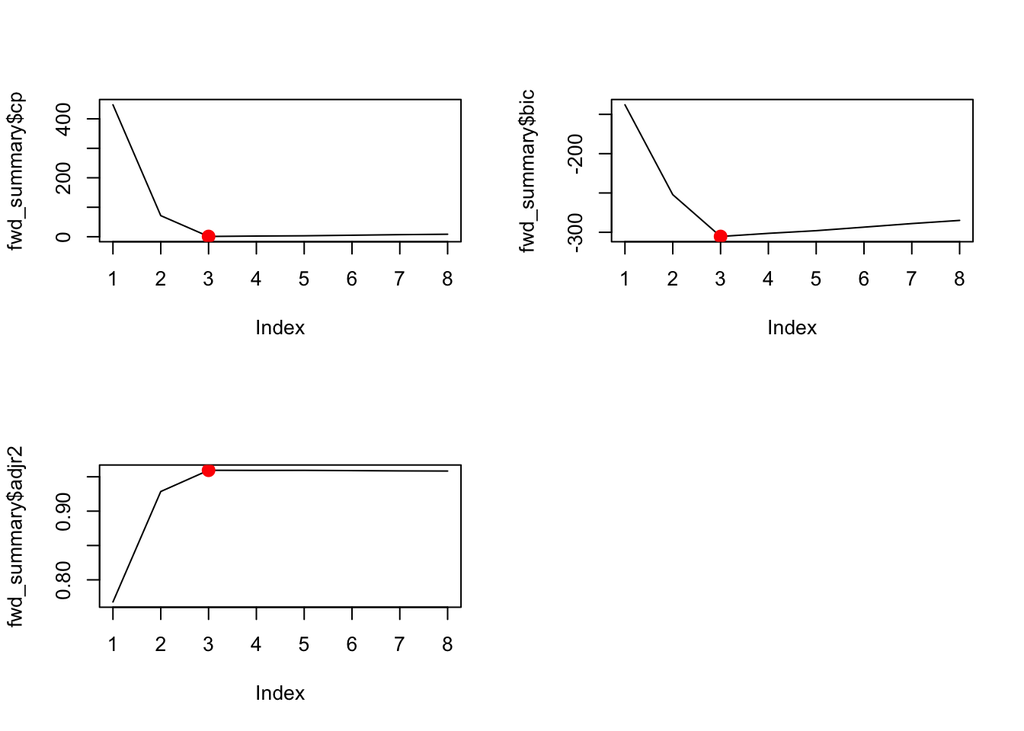

All three criteria for the forward selection model point to a three term model. The coefficients of the three term model are as follows:

-0.89634772 + 1.61126845 * x^2 -0.96515559 * x^3 - 0.03129297 * x^5

Intuitively, I find it surprising that the fifth degree polynomial makes the cut, particularly with the size of the coefficient. Therefore, we will refit two separate models with lm, so we can access the greater diagnostics.

```r
first_three <- lm(y ~ x + I(x^2) + I(x^3), data = reg_data)
summary(first_three)
```

```
##
## Call:
## lm(formula = y ~ x + I(x^2) + I(x^3), data = reg_data)
##
## Residuals:
##      Min       1Q   Median       3Q      Max
## -2.11671 -0.81526  0.07881  0.73185  2.86605
##
## Coefficients:
##             Estimate Std. Error t value Pr(>|t|)
## (Intercept) -0.90842    0.14025  -6.477 3.99e-09 ***
## x            0.14805    0.20055   0.738    0.462
## I(x^2)       1.63453    0.07124  22.943  < 2e-16 ***
## I(x^3)      -1.13605    0.05959 -19.066  < 2e-16 ***
## ---
## Signif. codes:  0 '***' 0.001 '**' 0.01 '*' 0.05 '.' 0.1 ' ' 1
##
## Residual standard error: 1.034 on 96 degrees of freedom
## Multiple R-squared:  0.9603, Adjusted R-squared:  0.9591
## F-statistic: 774.9 on 3 and 96 DF,  p-value: < 2.2e-16
```

```r
with_five <- lm(y ~ I(x^2) + I(x^3) + I(x^5), data = reg_data)
summary(with_five)
```

```
##
## Call:
## lm(formula = y ~ I(x^2) + I(x^3) + I(x^5), data = reg_data)
##
## Residuals:
##      Min       1Q   Median       3Q      Max
## -2.17637 -0.84931  0.06023  0.71938  2.81496
##
## Coefficients:
##             Estimate Std. Error t value Pr(>|t|)
## (Intercept) -0.89635    0.13959  -6.421 5.15e-09 ***
## I(x^2)       1.61127    0.07479  21.543  < 2e-16 ***
## I(x^3)      -0.96516    0.11139  -8.665 1.09e-13 ***
## I(x^5)      -0.03129    0.02570  -1.218    0.226
## ---
## Signif. codes:  0 '***' 0.001 '**' 0.01 '*' 0.05 '.' 0.1 ' ' 1
##
## Residual standard error: 1.029 on 96 degrees of freedom
## Multiple R-squared:  0.9607, Adjusted R-squared:  0.9595
## F-statistic: 782.8 on 3 and 96 DF,  p-value: < 2.2e-16
```

```r
par(mfrow=c(2,2))
plot(bkwd_summary$cp, type = "l")
points(which.min(bkwd_summary$cp), bkwd_summary$cp[which.min(bkwd_summary$cp)], col="red",cex=2,pch=20)
plot(bkwd_summary$bic, type = "l")
points(which.min(bkwd_summary$bic), bkwd_summary$bic[which.min(bkwd_summary$bic)], col="red",cex=2,pch=20)
plot(bkwd_summary$adjr2, type = "l")
points(which.max(bkwd_summary$adjr2), bkwd_summary$adjr2[which.max(bkwd_summary$adjr2)], col="red",cex=2,pch=20)
coef(bkwd_model, 2)
```

```
##              (Intercept) poly(x, 10, raw = TRUE)2 poly(x, 10, raw = TRUE)3
##               -0.9271256                1.6448130               -1.0968059
```

```r
coef_bkwd=coef(bkwd_model, 3)
coef_bkwd
```

```
##              (Intercept) poly(x, 10, raw = TRUE)2 poly(x, 10, raw = TRUE)3
##             -0.898990913              1.611310713             -1.033819810
## poly(x, 10, raw = TRUE)7
##             -0.003324615
```

```r
pred_bkwd=model_matrix[,names(coef_bkwd)]%*%coef_bkwd
mean((y-pred_bkwd)^2)
```

```
## [1] 1.020372
```

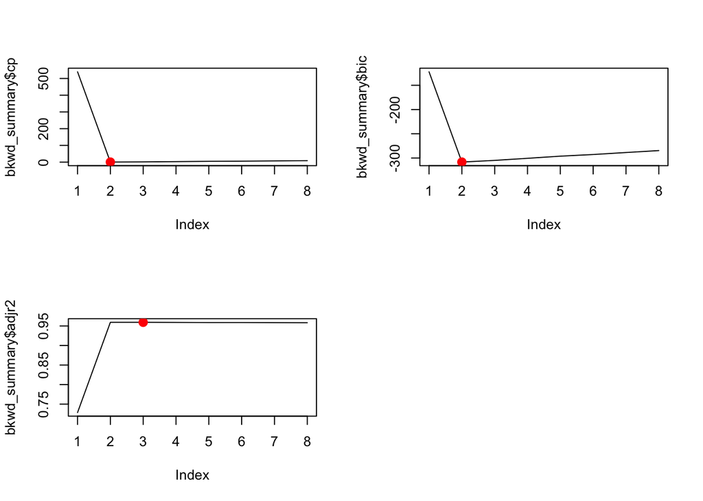

Both CP and BIC for the backwards selected model imply a two varible model, while the Adjusted R2 implies a three variable model. I inspect the two variable model now.

-0.9271256 + 1.6448130 * x^2 - 1.0968059 * x^3

In line with the best subset selction model.

##### E

```r
set.seed(2)
library(glmnet)
```

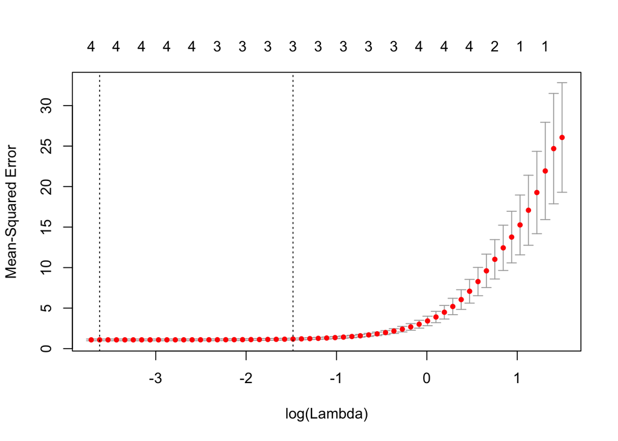

```r
cv.out=cv.glmnet(poly(x, 10, raw = TRUE),y,alpha=1)
plot(cv.out)
```

```r
bestlam=cv.out$lambda.min
print(bestlam)
```

```
## [1] 0.02676397
```

```r
lasso.mod=glmnet(poly(x, 10, raw = TRUE),y,alpha=1,lambda=bestlam)
predict(lasso.mod,type="coefficients",s=bestlam)
```

```
## 11 x 1 sparse Matrix of class "dgCMatrix"
##                       1
## (Intercept) -0.87395342
## 1           -0.07462526
## 2            1.58874227
## 3           -0.89708563
## 4            .
## 5           -0.04113589
## 6            .
## 7            .
## 8            .
## 9            .
## 10           .
```

```r
lasso.pred = predict(lasso.mod,s=bestlam,newx = poly(x, 10, raw = TRUE))
mean((lasso.pred-y)^2)
```

```
## [1] 1.017282
```

##### F

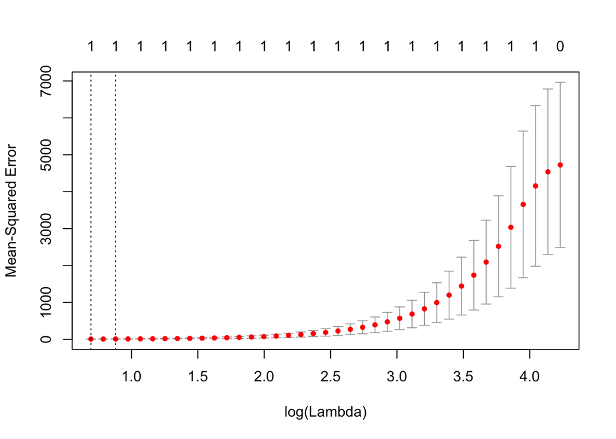

```r
b7 <- rnorm(1)
new_e <- rnorm(100)
new_y <- b0 + b7*x^7 + new_e
cv.out_new=cv.glmnet(poly(x, 10, raw = TRUE),new_y,alpha=1)
plot(cv.out_new)
```

```r
bestlam.new=cv.out_new$lambda.min
print(bestlam.new)
```

```
## [1] 2.003191
```

```r
lasso.mod.new=glmnet(poly(x, 10, raw = TRUE),new_y,alpha=1,lambda=bestlam.new)
predict(lasso.mod.new,type="coefficients",s=bestlam.new)
```

```
## 11 x 1 sparse Matrix of class "dgCMatrix"
##                      1
## (Intercept) -0.7585988
## 1            .
## 2            .
## 3            .
## 4            .
## 5            .
## 6            .
## 7           -0.8140526
## 8            .
## 9            .
## 10           .
```

```r
lasso.pred.new = predict(lasso.mod.new,s=bestlam.new,newx = poly(x, 10, raw = TRUE))
mean((lasso.pred.new-new_y)^2)
```

```
## [1] 5.251268
```

```r
reg_data <- data.frame(new_y, x)
reg_model <- regsubsets(new_y ~ poly(x, 10, raw = TRUE), data = reg_data)
reg_summary <- summary(reg_model)
print(reg_summary)
```

```
## Subset selection object
## Call: regsubsets.formula(new_y ~ poly(x, 10, raw = TRUE), data = reg_data)
## 10 Variables  (and intercept)
##                           Forced in Forced out
## poly(x, 10, raw = TRUE)1      FALSE      FALSE
## poly(x, 10, raw = TRUE)2      FALSE      FALSE
## poly(x, 10, raw = TRUE)3      FALSE      FALSE
## poly(x, 10, raw = TRUE)4      FALSE      FALSE
## poly(x, 10, raw = TRUE)5      FALSE      FALSE
## poly(x, 10, raw = TRUE)6      FALSE      FALSE
## poly(x, 10, raw = TRUE)7      FALSE      FALSE
## poly(x, 10, raw = TRUE)8      FALSE      FALSE
## poly(x, 10, raw = TRUE)9      FALSE      FALSE
## poly(x, 10, raw = TRUE)10     FALSE      FALSE
## 1 subsets of each size up to 8
## Selection Algorithm: exhaustive
##          poly(x, 10, raw = TRUE)1 poly(x, 10, raw = TRUE)2
## 1  ( 1 ) " "                      " "
## 2  ( 1 ) "*"                      " "
## 3  ( 1 ) "*"                      " "
## 4  ( 1 ) " "                      " "
## 5  ( 1 ) "*"                      " "
## 6  ( 1 ) "*"                      " "
## 7  ( 1 ) "*"                      " "
## 8  ( 1 ) "*"                      " "
##          poly(x, 10, raw = TRUE)3 poly(x, 10, raw = TRUE)4
## 1  ( 1 ) " "                      " "
## 2  ( 1 ) " "                      " "
## 3  ( 1 ) " "                      " "
## 4  ( 1 ) "*"                      " "
## 5  ( 1 ) " "                      " "
## 6  ( 1 ) "*"                      " "
## 7  ( 1 ) "*"                      " "
## 8  ( 1 ) "*"                      " "
##          poly(x, 10, raw = TRUE)5 poly(x, 10, raw = TRUE)6
## 1  ( 1 ) " "                      " "
## 2  ( 1 ) " "                      " "
## 3  ( 1 ) " "                      " "
## 4  ( 1 ) " "                      "*"
## 5  ( 1 ) "*"                      "*"
## 6  ( 1 ) "*"                      "*"
## 7  ( 1 ) "*"                      "*"
## 8  ( 1 ) "*"                      "*"
##          poly(x, 10, raw = TRUE)7 poly(x, 10, raw = TRUE)8
## 1  ( 1 ) "*"                      " "
## 2  ( 1 ) "*"                      " "
## 3  ( 1 ) "*"                      " "
## 4  ( 1 ) "*"                      "*"
## 5  ( 1 ) "*"                      "*"
## 6  ( 1 ) "*"                      "*"
## 7  ( 1 ) "*"                      "*"
## 8  ( 1 ) "*"                      "*"
##          poly(x, 10, raw = TRUE)9 poly(x, 10, raw = TRUE)10
## 1  ( 1 ) " "                      " "
## 2  ( 1 ) " "                      " "
## 3  ( 1 ) " "                      "*"
## 4  ( 1 ) " "                      " "
## 5  ( 1 ) " "                      " "
## 6  ( 1 ) " "                      " "
## 7  ( 1 ) "*"                      " "
## 8  ( 1 ) "*"                      "*"
```

```r
coef_full <- coef(reg_model, 1)
pred_full=model_matrix[,names(coef_full)]%*%coef_full
mean((pred_full-new_y)^2)
```

```
## [1] 1.238493
```

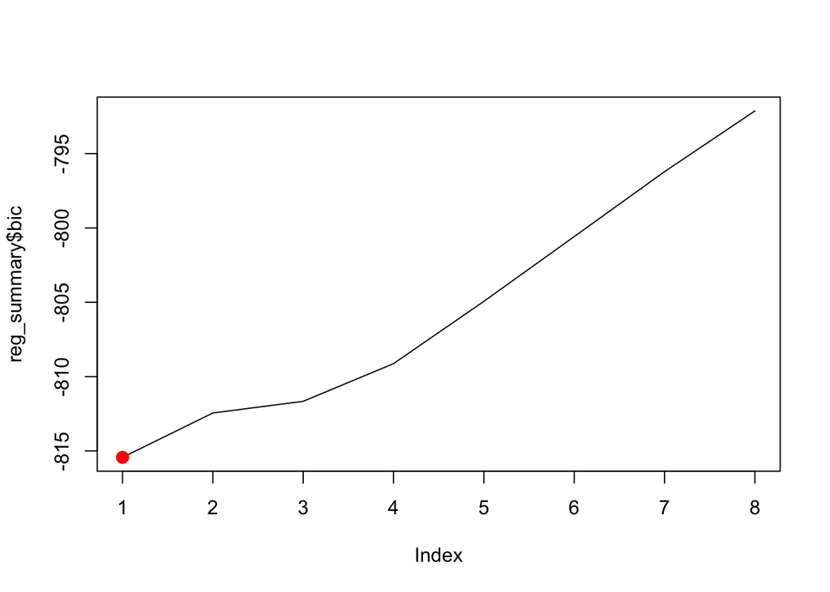

```r
plot(reg_summary$bic, type = "l")
points(which.min(reg_summary$bic), reg_summary$bic[which.min(reg_summary$bic)], col="red",cex=2,pch=20)
```

```r
#predict.regsubsets <- function(object ,newdata ,id ,...){
#  form=as.formula(object$call [[2]])
#  mat=model.matrix(form,newdata)
#  coefi=coef(object ,id=id)
#  xvars=names(coefi)
#  mat[,xvars]%*%coefi
#}


#k=10
#set.seed (10)
#folds=sample(1:k,nrow(reg_data),replace=TRUE)
#cv.errors=matrix(NA,k,10, dimnames=list(NULL, paste(1:10)))
#for (j in 1:10){
#  best.fit <- regsubsets(new_y ~ poly(x, 10, raw = TRUE), data = reg_data)
#  for (i in 1:10){
#    pred <- predict(best.fit,reg_data[folds==j,]$x,id=i)
#    cv.errors[j, i] <- mean((new_y[folds==j] - pred)^2)
#  }
#}

#mean.cv.errors <- apply(cv.errors ,2,mean)
#par(mfrow=c(1,1))
#plot(mean.cv.errors, type='b')
```

### Problem 9

##### A & B

```r
library(ISLR)
set.seed(5)
baseerror <- sd(College$Apps)
print(baseerror)
```

```
## [1] 3870.201
```

```r
train=sample(c(TRUE,FALSE), nrow(College),rep=TRUE)
test =(!train)
College.model <- lm(Apps~., data = College[train,])
summary(College.model)
```

```
##
## Call:
## lm(formula = Apps ~ ., data = College[train, ])
##
## Residuals:
##     Min      1Q  Median      3Q     Max
## -3268.3  -428.2   -49.1   342.8  6712.5
##
## Coefficients:
##               Estimate Std. Error t value Pr(>|t|)
## (Intercept) -299.91056  560.25372  -0.535 0.592746
## PrivateYes  -748.56067  195.64597  -3.826 0.000152 ***
## Accept         1.25809    0.07650  16.446  < 2e-16 ***
## Enroll        -0.62607    0.26406  -2.371 0.018242 *
## Top10perc     52.25447    7.92913   6.590 1.46e-10 ***
## Top25perc    -18.61224    6.64958  -2.799 0.005387 **
## F.Undergrad    0.16410    0.04216   3.892 0.000117 ***
## P.Undergrad   -0.00344    0.04011  -0.086 0.931707
## Outstate      -0.05447    0.02814  -1.935 0.053698 .
## Room.Board     0.25514    0.07327   3.482 0.000555 ***
## Books          0.31874    0.44288   0.720 0.472163
## Personal      -0.02566    0.09544  -0.269 0.788160
## PhD           -8.16289    5.95607  -1.371 0.171332
## Terminal      -6.10935    6.49490  -0.941 0.347486
## S.F.Ratio     -0.35326   17.59826  -0.020 0.983995
## perc.alumni   -6.32423    5.71219  -1.107 0.268930
## Expend         0.07994    0.02000   3.997 7.69e-05 ***
## Grad.Rate      9.03829    4.03176   2.242 0.025551 *
## ---
## Signif. codes:  0 '***' 0.001 '**' 0.01 '*' 0.05 '.' 0.1 ' ' 1
##
## Residual standard error: 1056 on 381 degrees of freedom
## Multiple R-squared:  0.9284, Adjusted R-squared:  0.9252
## F-statistic: 290.6 on 17 and 381 DF,  p-value: < 2.2e-16
```

```r
small.model <- lm(Apps ~ Private + Accept + Enroll + Top10perc + Top25perc + F.Undergrad + Outstate + Room.Board + Expend + Grad.Rate, data = College[train,])
summary(small.model)
```

```
##
## Call:
## lm(formula = Apps ~ Private + Accept + Enroll + Top10perc + Top25perc +
##     F.Undergrad + Outstate + Room.Board + Expend + Grad.Rate,
##     data = College[train, ])
##
## Residuals:
##     Min      1Q  Median      3Q     Max
## -3299.6  -466.8   -57.4   335.7  6816.1
##
## Coefficients:
##               Estimate Std. Error t value Pr(>|t|)
## (Intercept) -815.65122  333.62585  -2.445 0.014937 *
## PrivateYes  -574.06052  184.19666  -3.117 0.001966 **
## Accept         1.27377    0.07444  17.111  < 2e-16 ***
## Enroll        -0.67098    0.26289  -2.552 0.011083 *
## Top10perc     53.53896    7.85525   6.816 3.60e-11 ***
## Top25perc    -23.03334    6.41807  -3.589 0.000375 ***
## F.Undergrad    0.16390    0.04080   4.017 7.08e-05 ***
## Outstate      -0.07628    0.02705  -2.820 0.005049 **
## Room.Board     0.23410    0.07078   3.308 0.001029 **
## Expend         0.07195    0.01852   3.885 0.000120 ***
## Grad.Rate      7.63446    3.86068   1.977 0.048693 *
## ---
## Signif. codes:  0 '***' 0.001 '**' 0.01 '*' 0.05 '.' 0.1 ' ' 1
##
## Residual standard error: 1061 on 388 degrees of freedom
## Multiple R-squared:  0.9264, Adjusted R-squared:  0.9245
## F-statistic: 488.5 on 10 and 388 DF,  p-value: < 2.2e-16
```

```r
small.residual <- mean((College[test,]$Apps - predict(small.model, newdata = College[test,]))^2)
sqrt(small.residual)
```

```
## [1] 1136.328
```

##### C Ridge Regression

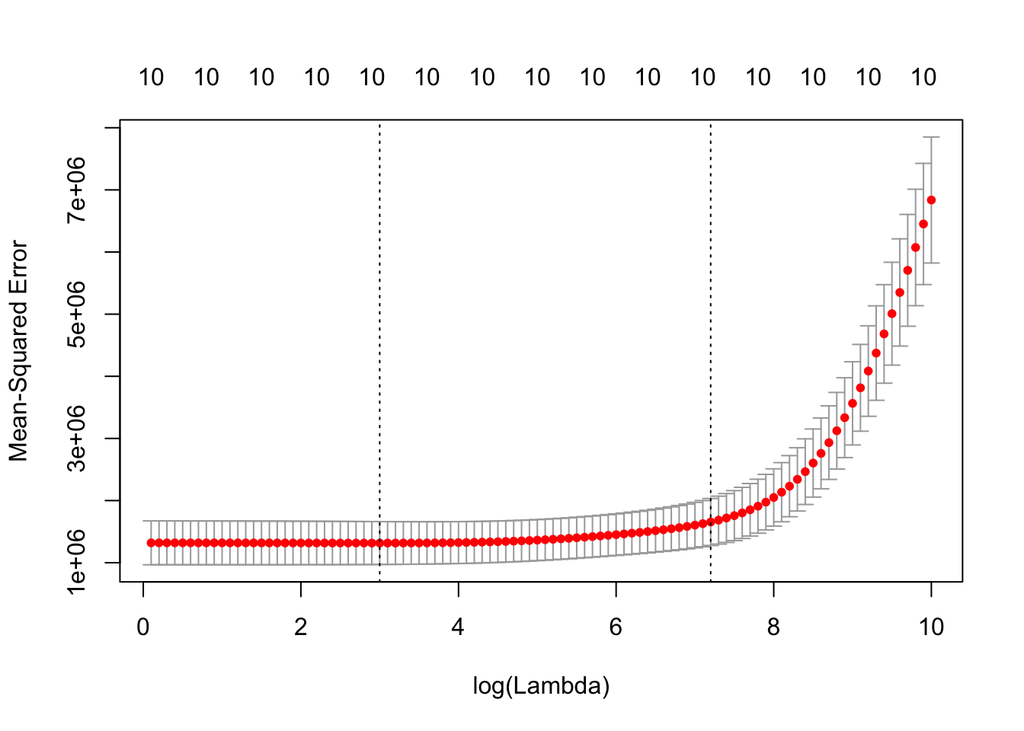

```r
library(glmnet)
y <- College$Apps
myvars <- c("Apps", "Private", "Accept", "Enroll", "Top10perc", "Top25perc", "F.Undergrad", "Outstate", "Room.Board", "Expend", "Grad.Rate")
x <- model.matrix(Apps ~., data = College[myvars])
cv.out=cv.glmnet(x[train,],y[train],alpha=0, lambda = exp(seq(0, 10, .1)))
plot(cv.out)
```

```r
lambda.min <- cv.out$lambda.min
lambda.model <- glmnet(x[train,],y[train],alpha=0, lambda = exp(seq(0, 10, .1)))
predict(lambda.model, s = lambda.min, type = "coefficients")
```

```
## 12 x 1 sparse Matrix of class "dgCMatrix"
##                         1
## (Intercept) -977.95371640
## (Intercept)    .
## PrivateYes  -590.03917851
## Accept         1.17999711
## Enroll        -0.37087369
## Top10perc     48.78929243
## Top25perc    -19.68603776
## F.Undergrad    0.14910660
## Outstate      -0.06890594
## Room.Board     0.24884148
## Expend         0.07334071
## Grad.Rate      7.25397164
```

```r
mean((y[test]-predict(lambda.model, s = lambda.min, newx = x[test,]))^2)^.5
```

```
## [1] 1180.251
```

##### D The Lasso

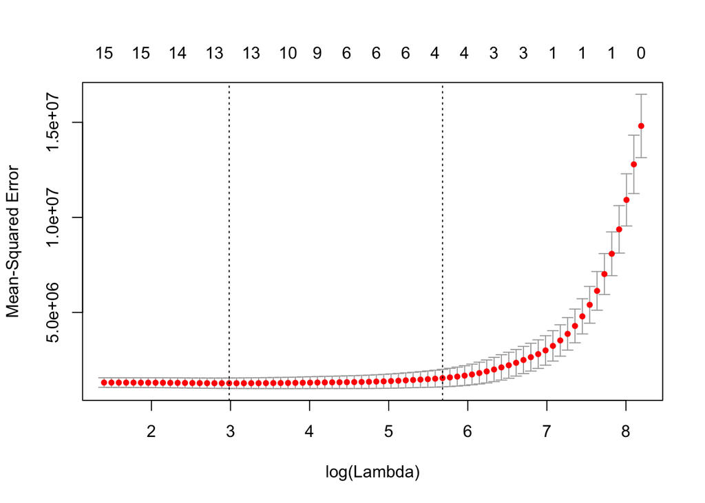

```r
big_x <- model.matrix(Apps ~., data = College)
cv.out=cv.glmnet(big_x[train,],y[train],alpha=1)
plot(cv.out)
```

```r
lambda.min <- cv.out$lambda.min
lambda.model <- glmnet(big_x[train,],y[train],alpha=1)
predict(lambda.model, s = lambda.min, type = "coefficients")
```

```
## 19 x 1 sparse Matrix of class "dgCMatrix"
##                         1
## (Intercept) -648.11523315
## (Intercept)    .
## PrivateYes  -721.58631488
## Accept         1.13252511
## Enroll         .
## Top10perc     37.15450184
## Top25perc     -5.71624117
## F.Undergrad    0.09806651
## P.Undergrad    .
## Outstate      -0.02399915
## Room.Board     0.23115069
## Books          0.11023780
## Personal       .
## PhD           -5.76381945
## Terminal      -5.86155668
## S.F.Ratio      .
## perc.alumni   -6.55073666
## Expend         0.07232631
## Grad.Rate      5.66539608
```

```r
mean((y[test]-predict(lambda.model, s = lambda.min, newx = big_x[test,]))^2)^.5
```

```
## [1] 1188.692
```

Interestingly, the lasso underperforms both ridge regression and OLS.

##### E

```r
library(pls)
```

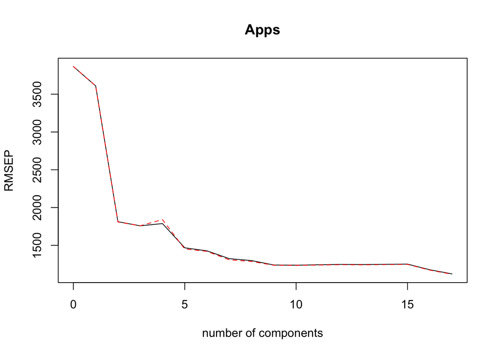

```r
set.seed(2)
pcr.fit=pcr(Apps~., data=College[train,] ,scale=TRUE, validation ="CV")
validationplot(pcr.fit, val.type = "RMSEP")
```

```r
summary(pcr.fit)
```

```
## Data:    X dimension: 399 17
##  Y dimension: 399 1
## Fit method: svdpc
## Number of components considered: 17
##
## VALIDATION: RMSEP
## Cross-validated using 10 random segments.
##        (Intercept)  1 comps  2 comps  3 comps  4 comps  5 comps  6 comps
## CV            3866     3610     1813     1758     1788     1468     1427
## adjCV         3866     3609     1809     1759     1841     1452     1420
##        7 comps  8 comps  9 comps  10 comps  11 comps  12 comps  13 comps
## CV        1324     1298     1240      1238      1243      1248      1246
## adjCV     1309     1287     1237      1235      1239      1244      1242
##        14 comps  15 comps  16 comps  17 comps
## CV         1249      1252      1177      1122
## adjCV      1245      1248      1172      1117
##
## TRAINING: % variance explained
##       1 comps  2 comps  3 comps  4 comps  5 comps  6 comps  7 comps
## X       31.26    56.77    64.01    69.72    75.35    80.26    84.13
## Apps    13.45    78.99    81.24    81.34    87.41    88.14    89.99
##       8 comps  9 comps  10 comps  11 comps  12 comps  13 comps  14 comps
## X       87.55    90.59     92.99     95.12     96.90     97.96     98.98
## Apps    90.20    90.54     90.57     90.68     90.69     90.74     90.76
##       15 comps  16 comps  17 comps
## X        99.50     99.84    100.00
## Apps     90.76     92.00     92.84
```

```r
pcr.pred <- predict(pcr.fit, College[test,], ncomp = 9)
mean((pcr.pred - College[test,]$Apps)^2)^.5
```

```
## [1] 1711.746
```

It looks like we can get away with 9 principal components.

The test error is 1700, which is much worse than the lasso or ridge regression. I thought this was an error at first, but when we set p=17 we recover the OLS solution

##### F

```r
set.seed(1)
pls.fit <- plsr(Apps~., data = College, subset = train, scale = TRUE, validation = "CV")
summary(pls.fit)
```

```
## Data:    X dimension: 399 17
##  Y dimension: 399 1
## Fit method: kernelpls
## Number of components considered: 17
##
## VALIDATION: RMSEP
## Cross-validated using 10 random segments.
##        (Intercept)  1 comps  2 comps  3 comps  4 comps  5 comps  6 comps
## CV            3866     1637     1398     1223     1212     1207     1170
## adjCV         3866     1634     1401     1220     1209     1201     1162
##        7 comps  8 comps  9 comps  10 comps  11 comps  12 comps  13 comps
## CV        1146     1137     1138      1137      1133      1137      1135
## adjCV     1140     1132     1132      1131      1128      1131      1130
##        14 comps  15 comps  16 comps  17 comps
## CV         1135      1135      1135      1135
## adjCV      1129      1130      1130      1130
##
## TRAINING: % variance explained
##       1 comps  2 comps  3 comps  4 comps  5 comps  6 comps  7 comps
## X       26.73    49.05    62.47    67.72    71.76    73.96    76.83
## Apps    82.83    87.35    90.73    91.22    91.72    92.44    92.64
##       8 comps  9 comps  10 comps  11 comps  12 comps  13 comps  14 comps
## X       80.07    82.56     84.69     87.54     90.94     93.92     96.15
## Apps    92.70    92.75     92.79     92.82     92.84     92.84     92.84
##       15 comps  16 comps  17 comps
## X        97.81     99.10    100.00
## Apps     92.84     92.84     92.84
```

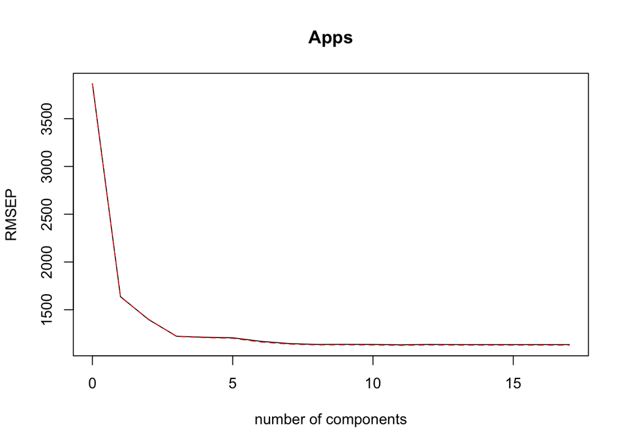

```r
validationplot(pls.fit, val.type = "RMSEP")
```

```r
pls.pred <- predict(pls.fit, College[test,], ncomp = 8)
mean((pls.pred - College[test,]$Apps)^2)^.5
```

```
## [1] 1148.936
```

Using 8 components, we get a test error of 1148. We chose 8 components based on the training set.

##### G

OLS fit: 1136 Ridge regression: 1180 Lasso: 1188 PCR: 1711 PLS: 1148

OLS (Using variable selection) and PLS both fit the best out of sample. This implies there is a problem with the varialble shrinkage and coming in ridge regression and the lasso, while PCR is wildly uncompetitive.

### Exercise 10

##### A & B

```r
set.seed(3)
library(Rlab)
x.matrix <- matrix(rnorm(20000), 1000, 20)
e.matrix <- matrix(rnorm(1000), 1000, 1)
s.matrix <- rbern(20, .25)
c.matrix <- rnorm(20)
y.matrix <- x.matrix %*% (s.matrix * c.matrix) + e.matrix
full.data <- cbind(y.matrix, x.matrix)
full.data.names <- c("y", paste0("x", 1:20, sept =""))
full.data <- data.frame(full.data)
colnames(full.data) <- full.data.names
train <- sample(1:1000, 100, replace = FALSE)
train.data <- full.data[train,]
inclusion.matrix <- data.frame(s.matrix*c.matrix, row.names = paste0("x", 1:20, sept =""))
print(inclusion.matrix)
```

```
##     s.matrix...c.matrix
## x1            0.0000000
## x2            0.9743443
## x3            0.0000000
## x4            0.0000000
## x5            0.0000000
## x6            0.0000000
## x7            0.0000000
## x8            0.0000000
## x9            0.0000000
## x10           0.0000000
## x11           0.8492042
## x12           0.0000000
## x13           0.0000000
## x14          -0.1672496
## x15           0.0000000
## x16           1.7110857
## x17          -1.2604083
## x18           0.2749471
## x19           0.0000000
## x20           0.4328446
```

##### C

```r
reg_model <- regsubsets(y ~., data = train.data, nvm = 20)
reg_summary <- summary(reg_model)
print(reg_summary)
```

```
## Subset selection object
## Call: regsubsets.formula(y ~ ., data = train.data, nvm = 20)
## 20 Variables  (and intercept)
##     Forced in Forced out
## x1      FALSE      FALSE
## x2      FALSE      FALSE
## x3      FALSE      FALSE
## x4      FALSE      FALSE
## x5      FALSE      FALSE
## x6      FALSE      FALSE
## x7      FALSE      FALSE
## x8      FALSE      FALSE
## x9      FALSE      FALSE
## x10     FALSE      FALSE
## x11     FALSE      FALSE
## x12     FALSE      FALSE
## x13     FALSE      FALSE
## x14     FALSE      FALSE
## x15     FALSE      FALSE
## x16     FALSE      FALSE
## x17     FALSE      FALSE
## x18     FALSE      FALSE
## x19     FALSE      FALSE
## x20     FALSE      FALSE
## 1 subsets of each size up to 20
## Selection Algorithm: exhaustive
##           x1  x2  x3  x4  x5  x6  x7  x8  x9  x10 x11 x12 x13 x14 x15 x16
## 1  ( 1 )  " " " " " " " " " " " " " " " " " " " " " " " " " " " " " " "*"
## 2  ( 1 )  " " " " " " " " " " " " " " " " " " " " " " " " " " " " " " "*"
## 3  ( 1 )  " " " " " " " " " " " " " " " " " " " " "*" " " " " " " " " "*"
## 4  ( 1 )  " " "*" " " " " " " " " " " " " " " " " "*" " " " " " " " " "*"
## 5  ( 1 )  " " "*" " " " " " " " " " " " " " " " " "*" " " " " " " " " "*"
## 6  ( 1 )  " " "*" " " " " " " " " " " " " " " " " "*" " " " " " " " " "*"
## 7  ( 1 )  " " "*" " " " " " " " " " " " " " " " " "*" " " "*" " " " " "*"
## 8  ( 1 )  " " "*" " " " " " " " " " " " " " " " " "*" "*" "*" " " " " "*"
## 9  ( 1 )  " " "*" "*" " " " " " " " " " " " " " " "*" "*" "*" " " " " "*"
## 10  ( 1 ) " " "*" "*" " " " " " " "*" " " " " " " "*" "*" "*" " " " " "*"
## 11  ( 1 ) " " "*" "*" "*" " " " " "*" " " " " " " "*" "*" "*" " " " " "*"
## 12  ( 1 ) "*" "*" "*" "*" " " " " "*" " " " " " " "*" "*" "*" " " " " "*"
## 13  ( 1 ) "*" "*" "*" "*" " " " " "*" " " " " " " "*" "*" "*" " " " " "*"
```

[output cut: 13 more lines]

```
## 6  ( 1 )  "*" "*" " " "*"
## 7  ( 1 )  "*" "*" " " "*"
## 8  ( 1 )  "*" "*" " " "*"
## 9  ( 1 )  "*" "*" " " "*"
## 10  ( 1 ) "*" "*" " " "*"
## 11  ( 1 ) "*" "*" " " "*"
## 12  ( 1 ) "*" "*" " " "*"
## 13  ( 1 ) "*" "*" "*" "*"
## 14  ( 1 ) "*" "*" " " "*"
## 15  ( 1 ) "*" "*" "*" "*"
## 16  ( 1 ) "*" "*" "*" "*"
## 17  ( 1 ) "*" "*" "*" "*"
## 18  ( 1 ) "*" "*" "*" "*"
## 19  ( 1 ) "*" "*" "*" "*"
## 20  ( 1 ) "*" "*" "*" "*"
```

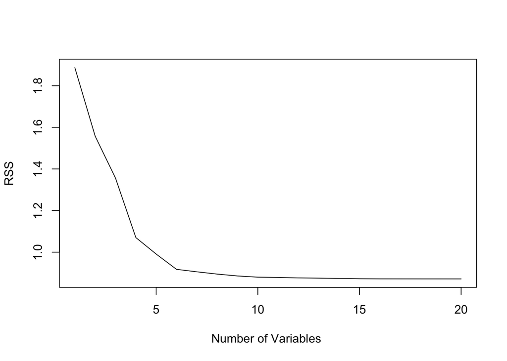

```r
plot(sqrt(reg_summary$rss/100),xlab="Number of Variables ",ylab="RSS", type="l")
```

##### D,E, & F

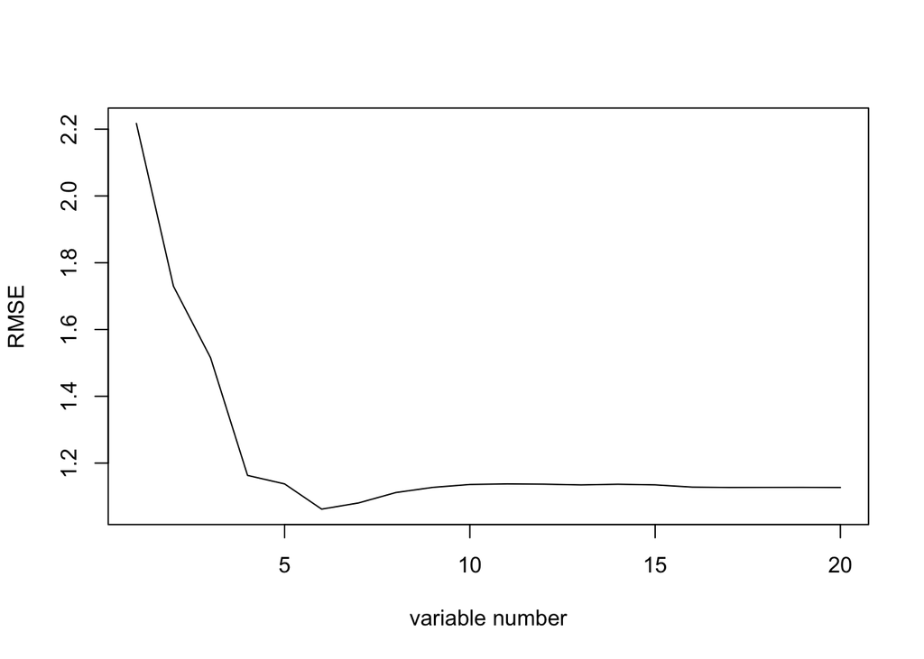

```r
predict.regsubsets <- function(object ,newdata ,id ,...){
  form=as.formula(object$call [[2]])
  mat=model.matrix(form,newdata)
  coefi=coef(object ,id=id)
  xvars=names(coefi)
  mat[,xvars]%*%coefi
}

test = rep(TRUE, 1000)
test[train] = FALSE
val.errors = rep(NA, 20)
beta.errors = rep(NA, 20)
inclusion.matrix["(Intercept)", "s.matrix...c.matrix"] = 0
for (i in 1:20){
  val.errors[i] = sqrt(mean((full.data[test, "y"] - predict(reg_model, newdata = full.data[test,], id = i))^2))
  inclusion.matrix[paste(i, "variable")] = 0
  inclusion.matrix[names(coef(reg_model, id = i)), paste(i, "variable")] = coef(reg_model, id = i)
  beta.errors[i] = sqrt(mean((inclusion.matrix[,paste(i, "variable")] - inclusion.matrix[,"s.matrix...c.matrix"])^2))
}
plot(val.errors, type = "l", xlab = "variable number", ylab = "RMSE")
```

```r
print(val.errors[which.min(val.errors)])
```

```
## [1] 1.062105
```

```r
which.min(val.errors)
```

```
## [1] 6
```

```r
print(inclusion.matrix)
```

```
##             s.matrix...c.matrix 1 variable 2 variable 3 variable
## x1                    0.0000000   0.000000  0.0000000  0.0000000
## x2                    0.9743443   0.000000  0.0000000  0.0000000
## x3                    0.0000000   0.000000  0.0000000  0.0000000
## x4                    0.0000000   0.000000  0.0000000  0.0000000
## x5                    0.0000000   0.000000  0.0000000  0.0000000
## x6                    0.0000000   0.000000  0.0000000  0.0000000
## x7                    0.0000000   0.000000  0.0000000  0.0000000
## x8                    0.0000000   0.000000  0.0000000  0.0000000
## x9                    0.0000000   0.000000  0.0000000  0.0000000
## x10                   0.0000000   0.000000  0.0000000  0.0000000
## x11                   0.8492042   0.000000  0.0000000  0.8128938
## x12                   0.0000000   0.000000  0.0000000  0.0000000
## x13                   0.0000000   0.000000  0.0000000  0.0000000
## x14                  -0.1672496   0.000000  0.0000000  0.0000000
## x15                   0.0000000   0.000000  0.0000000  0.0000000
## x16                   1.7110857   1.789953  1.6427732  1.6146220
## x17                  -1.2604083   0.000000 -1.0679525 -1.0626948
## x18                   0.2749471   0.000000  0.0000000  0.0000000
## x19                   0.0000000   0.000000  0.0000000  0.0000000
## x20                   0.4328446   0.000000  0.0000000  0.0000000
## (Intercept)           0.0000000  -0.255301 -0.1005733 -0.2210612
##             4 variable 5 variable 6 variable  7 variable  8 variable
## x1           0.0000000  0.0000000  0.0000000  0.00000000  0.00000000
## x2           0.7756444  0.7602090  0.8073750  0.83437534  0.83925974
## x3           0.0000000  0.0000000  0.0000000  0.00000000  0.00000000
## x4           0.0000000  0.0000000  0.0000000  0.00000000  0.00000000
## x5           0.0000000  0.0000000  0.0000000  0.00000000  0.00000000
## x6           0.0000000  0.0000000  0.0000000  0.00000000  0.00000000
## x7           0.0000000  0.0000000  0.0000000  0.00000000  0.00000000
## x8           0.0000000  0.0000000  0.0000000  0.00000000  0.00000000
## x9           0.0000000  0.0000000  0.0000000  0.00000000  0.00000000
## x10          0.0000000  0.0000000  0.0000000  0.00000000  0.00000000
## x11          0.9045766  0.9605666  0.9591224  0.98984465  1.01907000
## x12          0.0000000  0.0000000  0.0000000  0.00000000 -0.14895764
## x13          0.0000000  0.0000000  0.0000000  0.18294524  0.22068462
## x14          0.0000000  0.0000000  0.0000000  0.00000000  0.00000000
## x15          0.0000000  0.0000000  0.0000000  0.00000000  0.00000000
## x16          1.7128680  1.7190257  1.6958031  1.70300026  1.70198835
## x17         -1.1385106 -1.1769656 -1.2071755 -1.20938400 -1.21541252
```

[output cut: 55 more lines]

```
## x7          -0.07405632 -0.07395868
## x8           0.06235309  0.06173678
## x9           0.00000000 -0.00641193
## x10         -0.06204183 -0.06141229
## x11          0.99374092  0.99293181
## x12         -0.14446878 -0.14363378
## x13          0.21582767  0.21537122
## x14         -0.02567832 -0.02538199
## x15          0.01752782  0.01673091
## x16          1.72501634  1.72553757
## x17         -1.22415076 -1.22345942
## x18          0.40965945  0.40950393
## x19          0.05402857  0.05521736
## x20          0.32847567  0.32832264
## (Intercept) -0.05999531 -0.05983953
```

```r
fitted.model <- lm(y ~ x2 + x11 + x16 + x17 + x18 + x20 + x14, data = full.data[test,])
summary(fitted.model)
```

```
##
## Call:
## lm(formula = y ~ x2 + x11 + x16 + x17 + x18 + x20 + x14, data = full.data[test,
##     ])
##
## Residuals:
##     Min      1Q  Median      3Q     Max
## -2.9972 -0.6635 -0.0167  0.7003  3.3780
##
## Coefficients:
##              Estimate Std. Error t value Pr(>|t|)
## (Intercept)  0.006831   0.033884   0.202     0.84
## x2           0.973821   0.034362  28.340  < 2e-16 ***
## x11          0.841506   0.034243  24.575  < 2e-16 ***
## x16          1.726488   0.033239  51.941  < 2e-16 ***
## x17         -1.273684   0.032519 -39.167  < 2e-16 ***
## x18          0.308518   0.033646   9.169  < 2e-16 ***
## x20          0.366002   0.034042  10.752  < 2e-16 ***
## x14         -0.186408   0.033230  -5.610 2.71e-08 ***
## ---
## Signif. codes:  0 '***' 0.001 '**' 0.01 '*' 0.05 '.' 0.1 ' ' 1
##
## Residual standard error: 1.014 on 892 degrees of freedom
## Multiple R-squared:  0.8756, Adjusted R-squared:  0.8747
## F-statistic: 897.2 on 7 and 892 DF,  p-value: < 2.2e-16
```

##### G

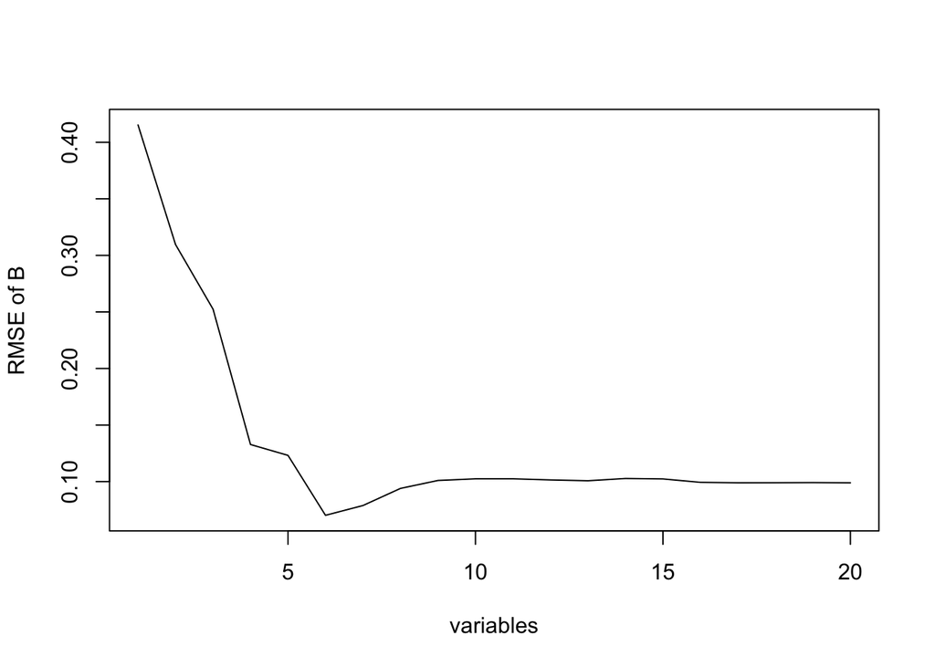

```r
plot(beta.errors, type = "l", xlab = "variables", ylab = "RMSE of B")
```

```r
beta.errors
```

```
##  [1] 0.41527071 0.30962636 0.25249724 0.13280533 0.12320691 0.07020176
##  [7] 0.07886532 0.09398792 0.10101721 0.10246589 0.10248072 0.10149956
## [13] 0.10076362 0.10276875 0.10237265 0.09936170 0.09898183 0.09903351
## [19] 0.09915296 0.09896792
```

The RMSE of our B estimates is minimized for the 6 variable model. This is in line with our out of sample estimates, but differs from our true model (7 variable versus 6 variable).

### Exercise 11

```r
library(MASS)
library(glmnet)
#loop through to generate the cross validation sets
k.fold.validation.list <- function(data, k){
  big.vec <- rep(1:k, ceiling(nrow(data)/k))
  fitted.vec <- big.vec[(-nrow(data)-1):(-ceiling(nrow(data)/k)*k)]
  return(fitted.vec)
}

train.length <- c(rep(TRUE, nrow(Boston)-100), rep(FALSE, 100))
set.seed(3)
train.length <- sample(train.length, nrow(Boston), replace = FALSE)
Boston.train <- Boston[train.length,]
Boston.test <- Boston[!train.length,]

Boston.train.crim <- as.matrix(Boston.train$crim)
Boston.train.x <- as.matrix(Boston.train[,!(names(Boston) %in% "crim")])
Boston.test.crim <- as.matrix(Boston.test$crim)
Boston.test.x <- as.matrix(Boston.test[,!(names(Boston) %in% "crim")])

#Overall variance of the test data
print(sd(Boston.test.crim))
```

```
## [1] 9.042514
```

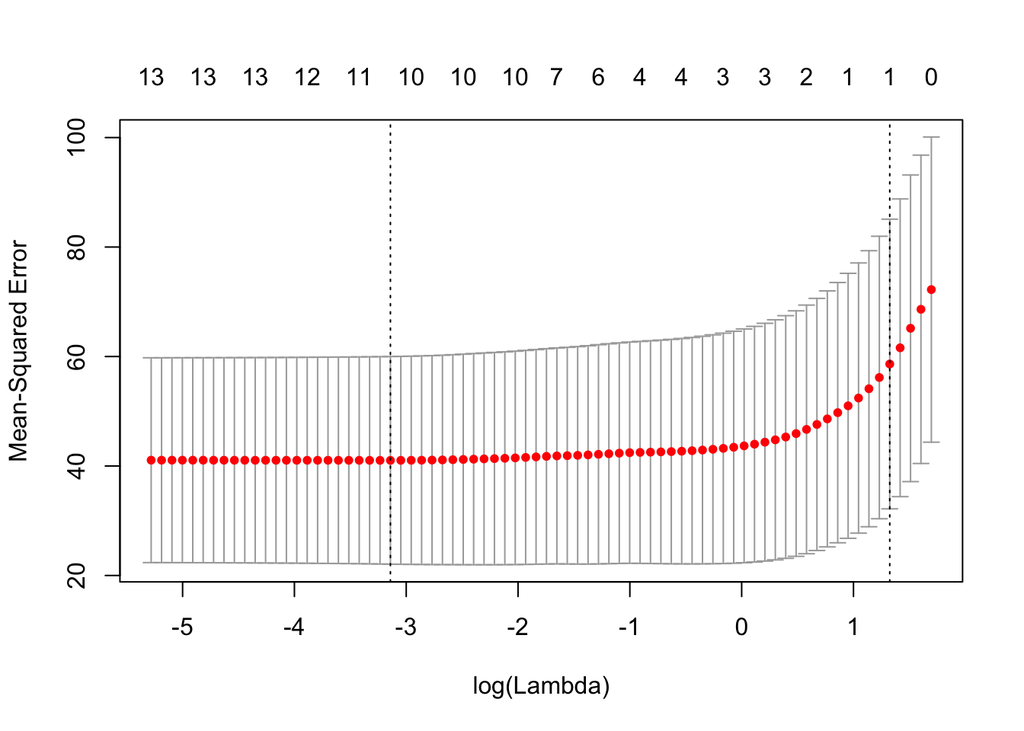

```r
#Fit the lasso data
set.seed(2)
lasso.model <- cv.glmnet(Boston.train.x, Boston.train.crim, alpha = 1)
plot(lasso.model)
```

```r
lasso.fit <- glmnet(Boston.train.x, Boston.train.crim, alpha = 1)
lasso.coef <- predict(lasso.fit, s = lasso.model$lambda.min, type = "coefficients")
print(lasso.coef)
```

```
## 14 x 1 sparse Matrix of class "dgCMatrix"
##                       1
## (Intercept) 11.31104036
## zn           0.03865410
## indus       -0.05721955
## chas        -0.91164549
## nox         -8.93121722
## rm           0.44651654
## age          .
## dis         -0.91663091
## rad          0.56572326
## tax          .
## ptratio     -0.24409989
## black        .
## lstat        0.12535948
## medv        -0.18560700
```

```r
#Test out of sample data
lasso.oos <- predict(lasso.model, s =lasso.model$lambda.min, newx = Boston.test.x)
lasso.oos.error <- sum((Boston.test.crim - lasso.oos)^2)
print(lasso.oos.error/100)^.5
```

```
## [1] 52.52689
```

```
## [1] 7.247544
```

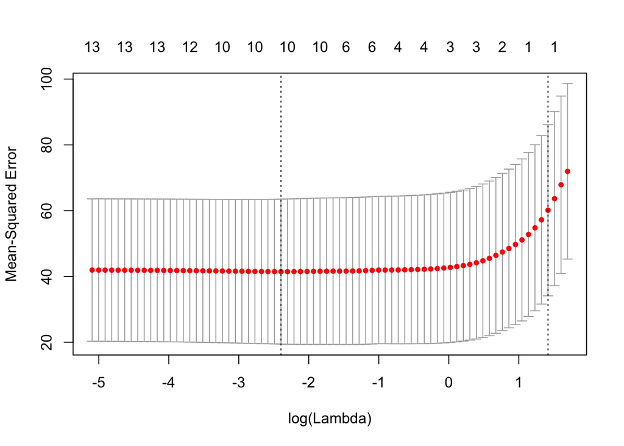

```r
#Fit the ridge regression data
set.seed(5)
ridge.model <- cv.glmnet(Boston.train.x, Boston.train.crim, alpha = 1)
plot(ridge.model)
```

```r
ridge.fit <- glmnet(Boston.train.x, Boston.train.crim, alpha = 1)
ridge.coef <- predict(ridge.fit, s = ridge.model$lambda.min, type = "coefficients")
print(ridge.coef)
```

```
## 14 x 1 sparse Matrix of class "dgCMatrix"
##                       1
## (Intercept)  8.06192288
## zn           0.03401396
## indus       -0.03854115
## chas        -0.85311676
## nox         -5.93696416
## rm           0.27983942
## age          .
## dis         -0.73413036
## rad          0.54705328
## tax          .
## ptratio     -0.17026377
## black        .
## lstat        0.12016393
## medv        -0.15646677
```

```r
#Test out of sample data
ridge.oos <- predict(ridge.model, s =ridge.model$lambda.min, newx = Boston.test.x)
ridge.oos.error <- sum((Boston.test.crim - ridge.oos)^2)
print(ridge.oos.error/100)^.5
```

```
## [1] 52.47304
```

```
## [1] 7.243828
```

```r
#Fit the pcr data
set.seed(10)
pcr.model <- pcr(crim ~., data = Boston.train, validation = "CV")
summary(pcr.model)
```

```
## Data:    X dimension: 406 13
##  Y dimension: 406 1
## Fit method: svdpc
## Number of components considered: 13
##
## VALIDATION: RMSEP
## Cross-validated using 10 random segments.
##        (Intercept)  1 comps  2 comps  3 comps  4 comps  5 comps  6 comps
## CV           8.511    6.821    6.884    6.873    6.870    6.803    6.705
## adjCV        8.511    6.817    6.876    6.866    6.863    6.795    6.697
##        7 comps  8 comps  9 comps  10 comps  11 comps  12 comps  13 comps
## CV       6.605    6.475    6.452     6.394     6.437     6.431     6.404
## adjCV    6.596    6.465    6.442     6.384     6.423     6.417     6.390
##
## TRAINING: % variance explained
##       1 comps  2 comps  3 comps  4 comps  5 comps  6 comps  7 comps
## X       80.19    96.86    98.99    99.67    99.88    99.93    99.97
## crim    36.85    36.89    37.09    37.17    38.56    40.56    42.70
##       8 comps  9 comps  10 comps  11 comps  12 comps  13 comps
## X       99.99   100.00    100.00    100.00    100.00    100.00
## crim    45.09    45.57     46.74     46.89     47.03     47.56
```

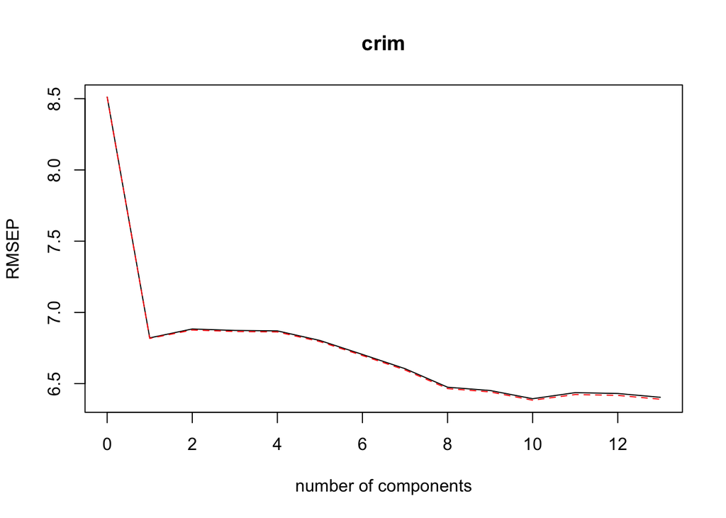

```r
validationplot(pcr.model, val.type = "RMSEP")
```

```r
pcr.pred <- predict(pcr.model, Boston.test, ncomp = 10)
print(mean((Boston.test.crim - as.matrix(pcr.pred))^2)^.5)
```

```
## [1] 7.226537
```

```r
#Fit the pls data
set.seed(10)
pls.model <- plsr(crim ~., data = Boston.train, validation = "CV", scale = TRUE)
summary(pls.model)
```

```
## Data:    X dimension: 406 13
##  Y dimension: 406 1
## Fit method: kernelpls
## Number of components considered: 13
##
## VALIDATION: RMSEP
## Cross-validated using 10 random segments.
##        (Intercept)  1 comps  2 comps  3 comps  4 comps  5 comps  6 comps
## CV           8.511    6.912    6.570    6.504    6.449    6.438    6.431
## adjCV        8.511    6.909    6.562    6.488    6.441    6.425    6.416
##        7 comps  8 comps  9 comps  10 comps  11 comps  12 comps  13 comps
## CV       6.414    6.406    6.403     6.403     6.404     6.404     6.404
## adjCV    6.400    6.392    6.390     6.390     6.390     6.390     6.390
##
## TRAINING: % variance explained
##       1 comps  2 comps  3 comps  4 comps  5 comps  6 comps  7 comps
## X       46.13    55.85    60.66    70.49    75.85    78.99    83.82
## crim    35.10    43.11    45.80    46.46    46.99    47.34    47.45
##       8 comps  9 comps  10 comps  11 comps  12 comps  13 comps
## X       86.20    88.21     91.32     96.42     97.98    100.00
## crim    47.53    47.56     47.56     47.56     47.56     47.56
```

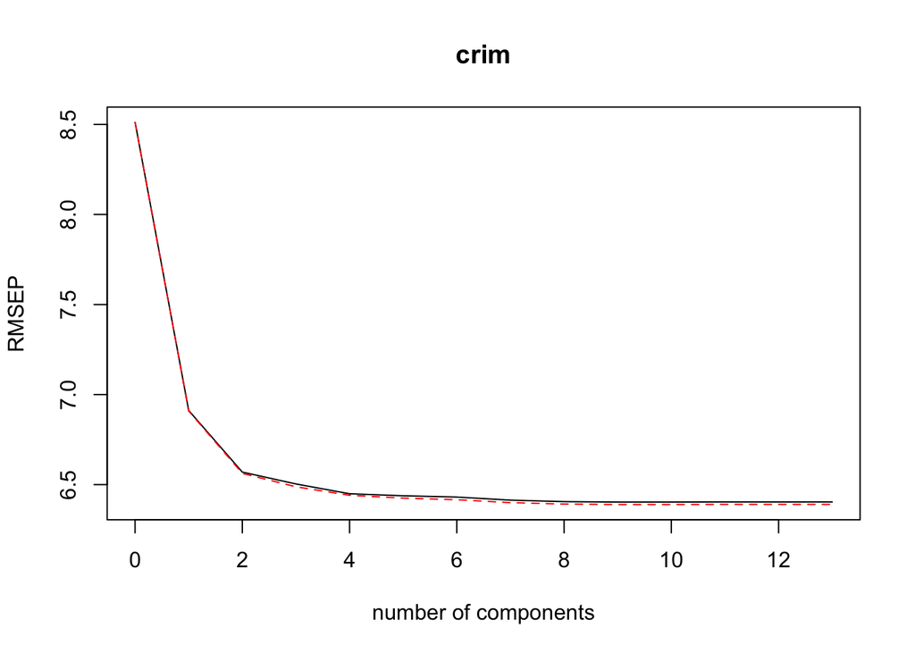

```r
validationplot(pls.model, val.type = "RMSEP")
```

```r
pls.pred <- predict(pls.model, Boston.test, ncomp = 8)
print(mean((Boston.test.crim - as.matrix(pls.pred))^2)^.5)
```

```
## [1] 7.269901
```